# R Notebook

#Ejercicio 2 - R

##Enunciado:

Se dispone del archivo CSV ‘Airbnb_Milan.csv’ con información sobre los Air Bnb de la ciudad de Milán en 2019. En el dataset, solamente aparecen apartamentos completos.

Con esta información, el alumno debe realizar los siguientes procesos de analítica:

- Cargar el archivo “Airbnb_Milan.csv” como dataframe.

```r
#En primer lugar, importamos las librerías:
library(tidyr)
library(dplyr)
library(ggplot2)
```

```r
df <- read.csv("Airbnb_Milan.csv", sep = ",", header = TRUE)
```

```r
#Mostramos las primeras filas del df, como referencia para futuros apartados
head(df)
```

|  | X | id | host_id | host_location | host_response_time | host_response_rate | host_is_superhost | host_total_listings_count | host_has_profile_pic | host_identity_verified | neighbourhood_cleansed | zipcode | latitude | longitude | room_type | accommodates | bathrooms | bedrooms | beds | bed_type | daily_price | security_deposit | cleaning_fee | guests_included | extra_people | minimum_nights | availability_30 | availability_60 | availability_90 | … |
| --- | --- | --- | --- | --- | --- | --- | --- | --- | --- | --- | --- | --- | --- | --- | --- | --- | --- | --- | --- | --- | --- | --- | --- | --- | --- | --- | --- | --- | --- | --- |
| 1 | 1 | 73892 | 387110 | 1 | 1 | 57 | 0 | 3 | 1 | 1 | 1 | 20121 | 45.47015 | 9.19134 | Entire home/apt | 2 | 3 | 1 | 1 | 1 | 94 | 1 | 45 | 1 | 0 | 2 | 29 | 59 | 89 | … |
| 2 | 2 | 74169 | 268127 | 1 | 1 | 57 | 0 | 1 | 1 | 0 | 1 | 20121 | 45.47169 | 9.18412 | Entire home/apt | 4 | 3 | 1 | 1 | 1 | 125 | 31 | 30 | 1 | 0 | 2 | 0 | 0 | 9 | … |
| 3 | 3 | 77958 | 387110 | 1 | 1 | 57 | 0 | 3 | 1 | 1 | 1 | 20121 | 45.47117 | 9.19135 | Entire home/apt | 2 | 3 | 1 | 1 | 1 | 100 | 1 | 45 | 1 | 0 | 2 | 29 | 59 | 89 | … |
| 4 | 4 | 93025 | 499743 | 1 | 1 | 57 | 0 | 1 | 1 | 0 | 1 | 20121 | 45.47204 | 9.19640 | Entire home/apt | 3 | 3 | 1 | 2 | 1 | 120 | 48 | 57 | 2 | 40 | 2 | 10 | 40 | 70 | … |
| 5 | 5 | 132705 | 391011 | 1 | 1 | 57 | 1 | 2 | 1 | 0 | 1 | 20135 | 45.45934 | 9.20609 | Entire home/apt | 2 | 3 | 0 | 1 | 3 | 70 | 13 | 45 | 1 | 0 | 30 | 27 | 57 | 87 | … |
| 6 | 6 | 141833 | 689467 | 1 | 0 | 29 | 0 | 8 | 1 | 1 | 1 | 20123 | 45.46022 | 9.18279 | Entire home/apt | 2 | 3 | 1 | 1 | 1 | 200 | 48 | 57 | 2 | 20 | 15 | 0 | 3 | 33 | … |

```r
#También mostramos el nombre de las columnas
colnames(df)
```

```
 [1] "X"
 [2] "id"
 [3] "host_id"
 [4] "host_location"
 [5] "host_response_time"
 [6] "host_response_rate"
 [7] "host_is_superhost"
 [8] "host_total_listings_count"
 [9] "host_has_profile_pic"
[10] "host_identity_verified"
[11] "neighbourhood_cleansed"
[12] "zipcode"
[13] "latitude"
[14] "longitude"
[15] "room_type"
```

[output cut: 46 more lines]

```r
#Y comprobamos la presencia de nulos con el resumen estadístico
summary(df)
```

```
       X              id              host_id
 Min.   :   1   Min.   :   23986   Min.   :    24054
 1st Qu.:2331   1st Qu.: 8225660   1st Qu.:  9780440
 Median :4662   Median :20797472   Median : 27896328
 Mean   :4662   Mean   :19080417   Mean   : 66233909
 3rd Qu.:6992   3rd Qu.:28883635   3rd Qu.:110852021
 Max.   :9322   Max.   :36463651   Max.   :272679812
 host_location    host_response_time host_response_rate
 Min.   :0.0000   Min.   :0.0000     Min.   : 1.00
 1st Qu.:1.0000   1st Qu.:1.0000     1st Qu.:57.00
 Median :1.0000   Median :1.0000     Median :57.00
 Mean   :0.9596   Mean   :0.8692     Mean   :53.26
 3rd Qu.:1.0000   3rd Qu.:1.0000     3rd Qu.:57.00
 Max.   :1.0000   Max.   :1.0000     Max.   :57.00
 host_is_superhost host_total_listings_count host_has_profile_pic
 Min.   :0.0000    Min.   :  0.00            Min.   :0.0000
 1st Qu.:0.0000    1st Qu.:  1.00            1st Qu.:1.0000
 Median :0.0000    Median :  2.00            Median :1.0000
 Mean   :0.2889    Mean   : 23.19            Mean   :0.9996
 3rd Qu.:1.0000    3rd Qu.:  7.00            3rd Qu.:1.0000
 Max.   :1.0000    Max.   :847.00            Max.   :1.0000
 host_identity_verified neighbourhood_cleansed    zipcode
 Min.   :0.0000         Min.   :1.000          Min.   :20021
 1st Qu.:0.0000         1st Qu.:2.000          1st Qu.:20124
 Median :0.0000         Median :4.000          Median :20135
 Mean   :0.4312         Mean   :4.504          Mean   :20136
 3rd Qu.:1.0000         3rd Qu.:7.000          3rd Qu.:20145
 Max.   :1.0000         Max.   :9.000          Max.   :20162
    latitude       longitude      room_type          accommodates
 Min.   :45.39   Min.   :9.069   Length:9322        Min.   : 1.00
 1st Qu.:45.46   1st Qu.:9.171   Class :character   1st Qu.: 2.00
 Median :45.47   Median :9.186   Mode  :character   Median : 4.00
 Mean   :45.47   Mean   :9.187                      Mean   : 3.59
 3rd Qu.:45.49   3rd Qu.:9.208                      3rd Qu.: 4.00
 Max.   :45.53   Max.   :9.269                      Max.   :16.00
   bathrooms         bedrooms           beds           bed_type
 Min.   : 1.000   Min.   : 0.000   Min.   : 0.000   Min.   :1.000
 1st Qu.: 3.000   1st Qu.: 1.000   1st Qu.: 1.000   1st Qu.:1.000
 Median : 3.000   Median : 1.000   Median : 2.000   Median :1.000
 Mean   : 3.357   Mean   : 1.218   Mean   : 2.098   Mean   :1.029
```

[output cut: 85 more lines]

```
 Max.   :1.00    Max.   :1.0000           Max.   :1.0000
 Long_term_stays_allowed    Doorman        Pets_allowed
 Min.   :0.0000          Min.   :0.0000   Min.   :0.0000
 1st Qu.:0.0000          1st Qu.:0.0000   1st Qu.:0.0000
 Median :0.0000          Median :0.0000   Median :0.0000
 Mean   :0.3029          Mean   :0.1627   Mean   :0.2171
 3rd Qu.:1.0000          3rd Qu.:0.0000   3rd Qu.:0.0000
 Max.   :1.0000          Max.   :1.0000   Max.   :1.0000
 Smoking_allowed  Suitable_for_events X24_hour_check_in
 Min.   :0.0000   Min.   :0.00000     Min.   :0.00000
 1st Qu.:0.0000   1st Qu.:0.00000     1st Qu.:0.00000
 Median :0.0000   Median :0.00000     Median :0.00000
 Mean   :0.1073   Mean   :0.03637     Mean   :0.08528
 3rd Qu.:0.0000   3rd Qu.:0.00000     3rd Qu.:0.00000
 Max.   :1.0000   Max.   :1.00000     Max.   :1.00000
```

- Crear un nuevo dataframe que contenga únicamente las siguientes columnas:
  - “host_is_superhost”
  - “host_identity_verified”
  - “bathrooms”
  - “bedrooms”
  - “daily_price”
  - “security_deposit”
  - “minimum_nights”
  - “number_of_reviews”
  - “review_scores_rating”

```r
#Para simplificar el código, se empleará la función 'select' de la librería dplyr, así como el operador pipe (%>%)
df <- df %>% select(host_is_superhost, host_identity_verified, bathrooms, bedrooms, daily_price, security_deposit, minimum_nights, number_of_reviews, review_scores_rating)
```

```r
#Comprobamos que el df tenga las columnas seleccionadas
colnames(df)
```

```
[1] "host_is_superhost"      "host_identity_verified"
[3] "bathrooms"              "bedrooms"
[5] "daily_price"            "security_deposit"
[7] "minimum_nights"         "number_of_reviews"
[9] "review_scores_rating"
```

- Cambiar los factores de la variable “host_is_superhost” de 0, 1 a: “SI” y, “NO”. (investigar la función recode).

```r
#'recode' es otra función de la librería dplyr. Imita el funcionamiento de 'switch', permitiendo cambiar el valor de los factores
df$host_is_superhost <- recode(df$host_is_superhost, '0' = "NO", '1' = "SI")
```

```r
head(df)
```

|  | host_is_superhost | host_identity_verified | bathrooms | bedrooms | daily_price | security_deposit | minimum_nights | number_of_reviews | review_scores_rating |
| --- | --- | --- | --- | --- | --- | --- | --- | --- | --- |
| 1 | NO | 1 | 3 | 1 | 94 | 1 | 2 | 84 | 94 |
| 2 | NO | 0 | 3 | 1 | 125 | 31 | 2 | 3 | 100 |
| 3 | NO | 1 | 3 | 1 | 100 | 1 | 2 | 70 | 97 |
| 4 | NO | 0 | 3 | 1 | 120 | 48 | 2 | 57 | 97 |
| 5 | SI | 0 | 3 | 0 | 70 | 13 | 30 | 44 | 90 |
| 6 | NO | 1 | 3 | 1 | 200 | 48 | 15 | 79 | 98 |

- Cambiar los factores de la variable “host_identity_verified” de 0, 1 a: “VERIFICA” y “NO VERIFICA”.

```r
df$host_identity_verified <- recode(df$host_identity_verified, '0' = "NO VERIFICA", '1' = "VERIFICA")
```

```r
head(df)
```

|  | host_is_superhost | host_identity_verified | bathrooms | bedrooms | daily_price | security_deposit | minimum_nights | number_of_reviews | review_scores_rating |
| --- | --- | --- | --- | --- | --- | --- | --- | --- | --- |
| 1 | NO | VERIFICA | 3 | 1 | 94 | 1 | 2 | 84 | 94 |
| 2 | NO | NO VERIFICA | 3 | 1 | 125 | 31 | 2 | 3 | 100 |
| 3 | NO | VERIFICA | 3 | 1 | 100 | 1 | 2 | 70 | 97 |
| 4 | NO | NO VERIFICA | 3 | 1 | 120 | 48 | 2 | 57 | 97 |
| 5 | SI | NO VERIFICA | 3 | 0 | 70 | 13 | 30 | 44 | 90 |
| 6 | NO | VERIFICA | 3 | 1 | 200 | 48 | 15 | 79 | 98 |

- Mostrar un resumen estadístico de los datos.

```r
summary(df)
```

```
 host_is_superhost  host_identity_verified   bathrooms
 Length:9322        Length:9322            Min.   : 1.000
 Class :character   Class :character       1st Qu.: 3.000
 Mode  :character   Mode  :character       Median : 3.000
                                           Mean   : 3.357
                                           3rd Qu.: 3.000
                                           Max.   :17.000
    bedrooms       daily_price     security_deposit
 Min.   : 0.000   Min.   :  10.0   Min.   :  1.00
 1st Qu.: 1.000   1st Qu.:  59.0   1st Qu.:  1.00
 Median : 1.000   Median :  75.0   Median :  1.00
 Mean   : 1.218   Mean   : 103.7   Mean   : 21.71
 3rd Qu.: 2.000   3rd Qu.: 107.0   3rd Qu.: 48.00
 Max.   :10.000   Max.   :3000.0   Max.   :143.00
 minimum_nights    number_of_reviews review_scores_rating
 Min.   :  1.000   Min.   :  1.00    Min.   : 20.00
 1st Qu.:  1.000   1st Qu.:  4.00    1st Qu.: 90.00
 Median :  2.000   Median : 14.00    Median : 95.00
 Mean   :  3.205   Mean   : 39.64    Mean   : 93.15
 3rd Qu.:  2.000   3rd Qu.: 44.00    3rd Qu.: 99.00
 Max.   :365.000   Max.   :791.00    Max.   :100.00
```

- Filtrar el dataset por apartamentos cuyo mínimo de noches sea igual o menor que siete.

```r
df <- df %>% filter(minimum_nights <= 7)
```

```r
head(df)
```

|  | host_is_superhost | host_identity_verified | bathrooms | bedrooms | daily_price | security_deposit | minimum_nights | number_of_reviews | review_scores_rating |
| --- | --- | --- | --- | --- | --- | --- | --- | --- | --- |
| 1 | NO | VERIFICA | 3 | 1 | 94 | 1 | 2 | 84 | 94 |
| 2 | NO | NO VERIFICA | 3 | 1 | 125 | 31 | 2 | 3 | 100 |
| 3 | NO | VERIFICA | 3 | 1 | 100 | 1 | 2 | 70 | 97 |
| 4 | NO | NO VERIFICA | 3 | 1 | 120 | 48 | 2 | 57 | 97 |
| 5 | SI | NO VERIFICA | 5 | 1 | 700 | 1 | 1 | 72 | 96 |
| 6 | NO | NO VERIFICA | 3 | 1 | 250 | 73 | 1 | 126 | 98 |

- ¿Cuál es el precio medio por día de una habitación en función de si el anfitrión tiene verificado o no su perfil?

```r
#tapply es una función derivada de apply, aconsejable para dataframes. Realiza una operación en función de un vector de factores (en este caso, 'NO VERIFICA' y 'VERIFICA')
tapply(df$daily_price, df$host_identity_verified, mean)
```

```
NO VERIFICA    VERIFICA
   103.7517    103.8976
```

- Quién tiene más número de reseñas, ¿un super host o no super host?

```r
tapply(df$number_of_reviews, df$host_is_superhost, sum)
```

```
    NO     SI
201499 163265
```

Como podemos observar, los super host tienen menor número de reseñas.

- Sobre la estadística anterior ¿quién tiene la puntuación media más alta?

```r
tapply(df$review_scores_rating, df$host_is_superhost, mean)
```

```
      NO       SI
91.65573 96.93548
```

Los super host tienen la puntuación media más alta.

- Crea un vector categórico llamado “CATEGORÍA”, en función de que, si para la puntuación de las reseñas tiene de 0 a 49, sea “NO ACONSEJABLE”; de 50 a 75 sea “ESTÁNDAR”; y de 76 a 100 sea “TOP”.

```r
#Primero, creamos una función para determinar el valor a asignar
categoria <- function(puntuacion) {
  if (puntuacion >= 76) {
    return ("TOP")
  } else if (puntuacion >= 50) {
    return("ESTÁNDAR")
  } else {
    return("NO ACONSEJABLE")
  }
}
```

```r
#Usamos la función mutate, de la librería dplyr, para agregar una nueva columna.
#Sapply recibirá una lista (la columna con las puntuaciones) y devolverá un vector.
df <- df %>% mutate(CATEGORÍA = sapply(review_scores_rating, categoria))
```

```r
head(df)
```

|  | host_is_superhost | host_identity_verified | bathrooms | bedrooms | daily_price | security_deposit | minimum_nights | number_of_reviews | review_scores_rating | CATEGORÍA |
| --- | --- | --- | --- | --- | --- | --- | --- | --- | --- | --- |
| 1 | NO | VERIFICA | 3 | 1 | 94 | 1 | 2 | 84 | 94 | TOP |
| 2 | NO | NO VERIFICA | 3 | 1 | 125 | 31 | 2 | 3 | 100 | TOP |
| 3 | NO | VERIFICA | 3 | 1 | 100 | 1 | 2 | 70 | 97 | TOP |
| 4 | NO | NO VERIFICA | 3 | 1 | 120 | 48 | 2 | 57 | 97 | TOP |
| 5 | SI | NO VERIFICA | 5 | 1 | 700 | 1 | 1 | 72 | 96 | TOP |
| 6 | NO | NO VERIFICA | 3 | 1 | 250 | 73 | 1 | 126 | 98 | TOP |

```r
#Comprobamos que la función se haya aplicado como se tenía previsto (que haya varios tipos de categorías)
table(df$CATEGORÍA)
```

```
      ESTÁNDAR NO ACONSEJABLE            TOP
           251             37           8717
```

```r
#Y, finalmente, le cambiamos el tipo a la columna 'CATEGORÍA' por factor
df$CATEGORÍA <- as.factor(df$CATEGORÍA)
```

```r
#Comprobamos que el tipo de la columna haya cambiado
str(df)
```

```
'data.frame':   9005 obs. of  10 variables:
 $ host_is_superhost     : chr  "NO" "NO" "NO" "NO" ...
 $ host_identity_verified: chr  "VERIFICA" "NO VERIFICA" "VERIFICA" "NO VERIFICA" ...
 $ bathrooms             : int  3 3 3 3 5 3 3 3 3 3 ...
 $ bedrooms              : int  1 1 1 1 1 1 1 1 1 1 ...
 $ daily_price           : int  94 125 100 120 700 250 100 280 320 240 ...
 $ security_deposit      : int  1 31 1 48 1 73 13 1 1 1 ...
 $ minimum_nights        : int  2 2 2 2 1 1 1 1 1 1 ...
 $ number_of_reviews     : int  84 3 70 57 72 126 377 22 31 1 ...
 $ review_scores_rating  : int  94 100 97 97 96 98 94 95 95 40 ...
 $ CATEGORÍA             : Factor w/ 3 levels "ESTÁNDAR","NO ACONSEJABLE",..: 3 3 3 3 3 3 3 3 3 2 ...
```

- Mostrar las frecuencias de la variable CATEGORÍA.

```r
table(df$CATEGORÍA)
```

```
      ESTÁNDAR NO ACONSEJABLE            TOP
           251             37           8717
```

- Obtener el histograma del precio por día.

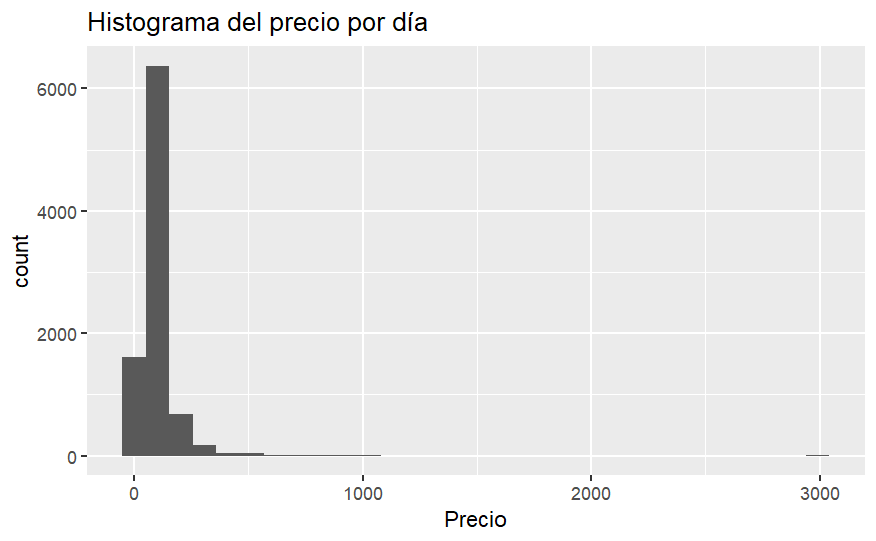

```r
#Podemos observar como la mayoría de los airbnb tienen un precio inferior a 500 por día
ggplot(df) +
  geom_histogram(mapping = aes(daily_price)) +
  ggtitle("Histograma del precio por día") +
  xlab("Precio")
```

- Estudiar la relación entre los dormitorios y baños de forma gráfica.

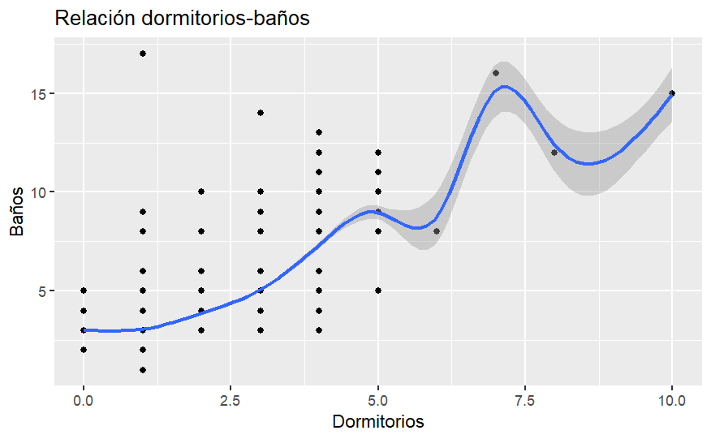

```r
#El diagrama de dipersión (geom_point) muestra la relación entre dos variables. En este caso, y como demuestra la recta de ajuste (geom_smooth), los baños y los dormitorios tienen una correlación positiva.
#Es decir, cuantos más dormitorios hay en un airbnb, mayor es el número de baños
ggplot(df) +
  geom_point(mapping = aes(x = bedrooms, y = bathrooms)) +
  geom_smooth(aes(bedrooms, bathrooms)) +
  ggtitle("Relación dormitorios-baños") +
  xlab("Dormitorios") +
  ylab("Baños")
```

- Mostrar un histograma del número de reseñas en función de si es un usuario verificado o no.

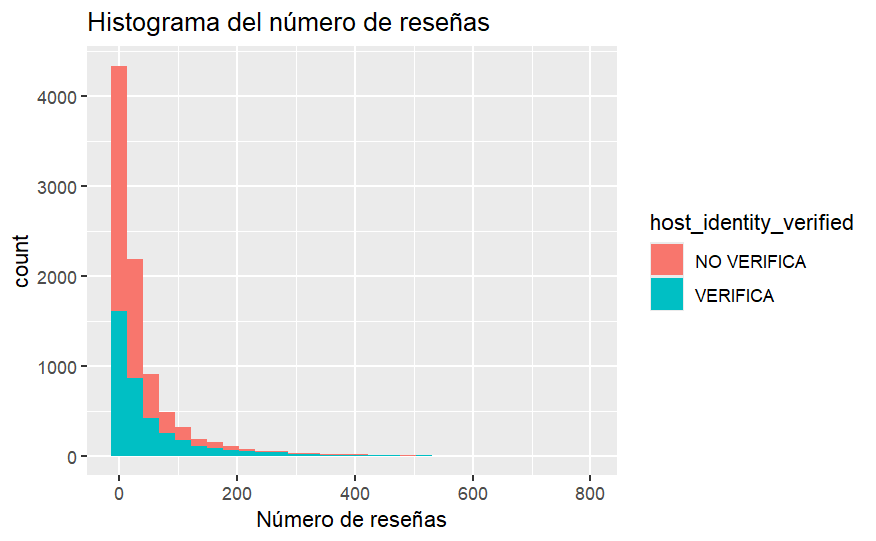

```r
#El gráfico muestra la frecuencia acumulada en función de si es un usuario verificado o no
ggplot(df) +
  geom_histogram(mapping = aes(number_of_reviews, fill = host_identity_verified)) +
  ggtitle("Histograma del número de reseñas") +
  xlab("Número de reseñas")
```

- Mostrar un histograma por cada valor de “CATEGORÍA” en el que se enseñe la cuantía del depósito de seguridad en función de si el anfitrión es super host o no.

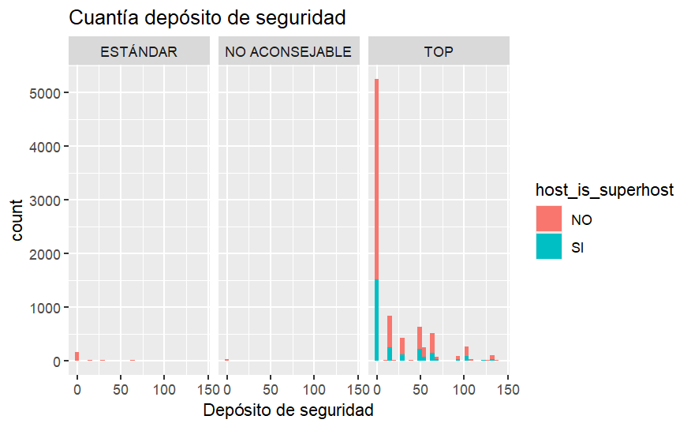

```r
#En este caso, usamos 'facetting' para mostrar tantas gráficas como valores únicos tenga la variable 'CATEGORÍA'
ggplot(df) +
  geom_histogram(mapping = aes(security_deposit, fill = host_is_superhost)) +
  facet_wrap(~CATEGORÍA) +
  ggtitle("Cuantía depósito de seguridad") +
  xlab("Depósito de seguridad")
```